# Exploring the BRFSS data

## Setup

### Load packages

```r
library(ggplot2)
library(dplyr)
```

### Load data

```r
load("brfss2013.RData")
```

## Part 1: Data

**what is this data all about?**

This data is about the general health status and health related problems of US citizens with age above 18yo. This data is representative of the whole US adult population as it was collected by BFRSS from randomly selected adults, the data “brfss2013” contains *330* variables for *491775* patients.

**what is this data collected for?**

the data collected under the BRFSS project will serve to monitor trends and draw meaningful insights in order to establish and track state and local health objectives, plan health programs, implement disease prevention and health promotion activities…

Since BRFSS conducts landline telephone and cellular telephone-based surveys. this data is collected in a stratified random sampling and no experiment had been forced, this is an observational study that is generalizable and does not lead to concluding any causality.

## Part 2: Research questions

**Research quesion 1:** My first research question involves how sleep-time of an adult US citizen might be related to any depressive disorder. In other words, does insomnia has anything to do with depression?

**Research quesion 2:** The next research question involves how smoking habits differ from women to men in the US among adults, and who is more vulnerable to asthma is they are a heavy smoker.

**Research quesion 3:** And finally, the last research question i wanna address is how does diabetes spread change from men to women since diabetes is a very common disease in the US.

## Part 3: Exploratory data analysis

**Research quesion 1:**

```r
vect<- brfss2013 %>%
  filter(sleptim1<5,!is.na(sleptim1),!is.na(addepev2)) %>%
  group_by(addepev2) %>%
  summarise(count=n())
```

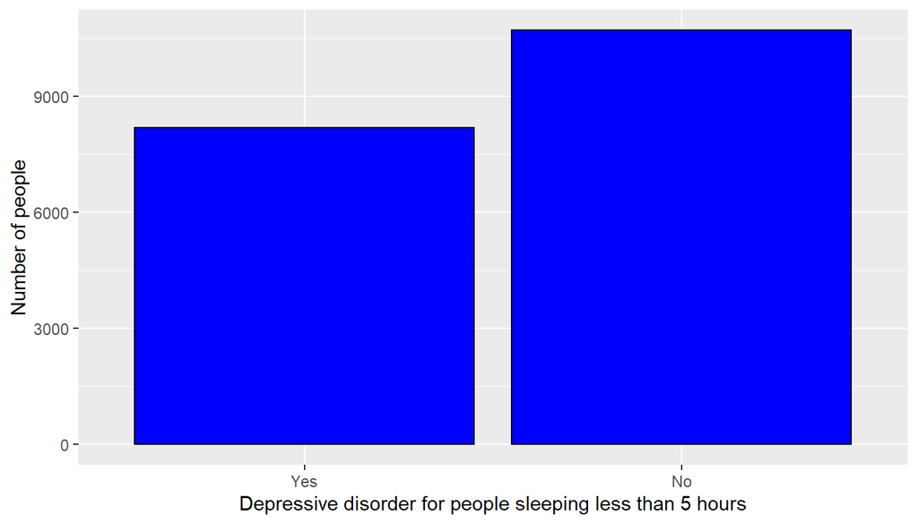

```r
ggplot(data=vect,aes(x=addepev2,y=count))+geom_bar(stat="identity",color='black',fill='blue')+xlab("Depressive disorder for people sleeping less than 5 hours")+ylab("Number of people")
```

**from the graph shown** The difference in the number of people having depression and those who don’t is not substantial, so there seem to be no correlation between sleep-time and depression, but we can’t draw any conclusions since we suspect existence of other factors who might be interfering and leading to this result.

**Research quesion 2:**

```r
v1 <- brfss2013 %>%
  filter(smoke100=="Yes",!is.na(asthma3)) %>%
  group_by(sex) %>%
  summarise(count=n())
v2 <- brfss2013 %>%
  filter(smoke100=="Yes",!is.na(asthma3),asthma3=="Yes") %>%
  group_by(sex,asthma3) %>%
  summarise(count=n())
```

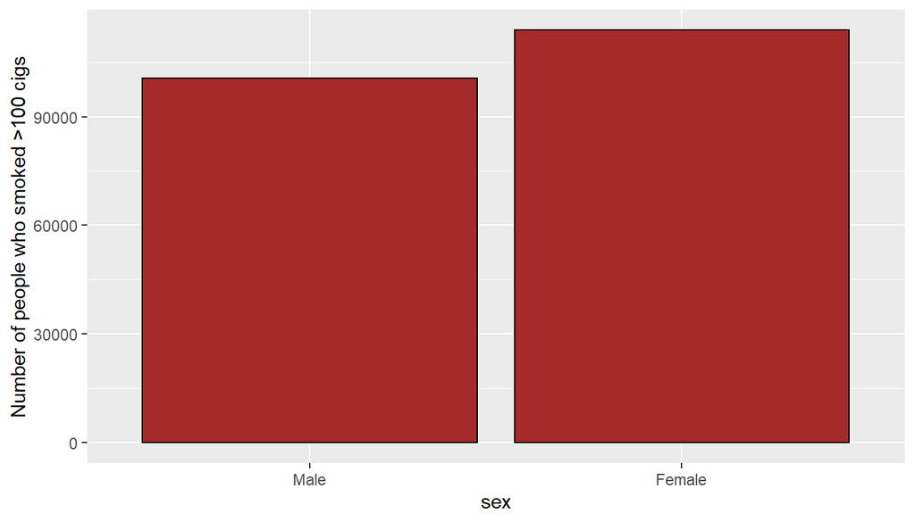

```r
ggplot(data=v1,aes(x=sex,y=count))+geom_bar(stat="identity",color='black',fill='brown')+xlab("sex")+ylab("Number of people who smoked >100 cigs")
```

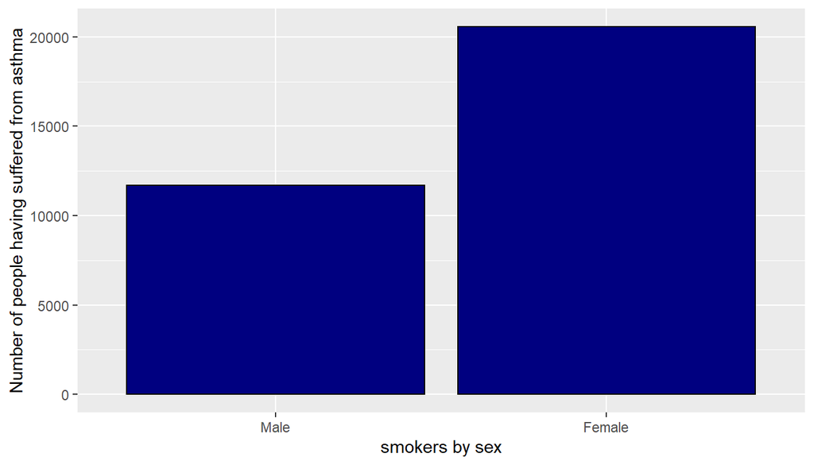

```r
ggplot(data=v2,aes(x=sex,y=count))+geom_bar(stat="identity",color='black',fill='navy')+xlab("smokers by sex")+ylab("Number of people having suffered from asthma")
```

**Research quesion 3:**

```r
v <- brfss2013 %>%
  filter(diabete3=="Yes",!is.na(sex))%>%
  group_by(sex)%>%
  summarise(count=n())
```

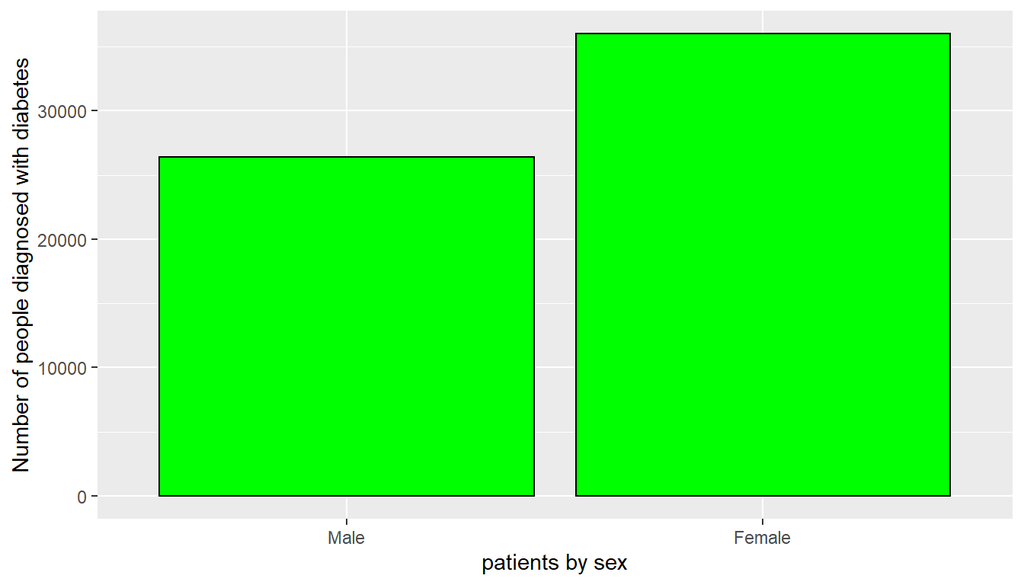

```r
ggplot(data=v,aes(x=sex,y=count))+geom_bar(stat="identity",color='black',fill='green')+xlab("patients by sex")+ylab("Number of people diagnosed with diabetes")
```

**From the bar graph**, we can clearly see that the number females having diabetes is higher than the number for men. From this visualization, we can , to a certain extent say that, female in the US are more likely to have diabetes than men by a not so substantial difference. However, this is only deducted from the data collected by BRFSS. generalizing it to the whole population can be influenced by many external factors.